# Gemini 4 or Gemma 4? It Depends.

This article provides a step by step guide to comparing the new Gemini 4 models with Gemma 4 on equal terms. Seven models, Gemma 4 26B and 31B, Gemini 3.5 Flash-Lite and 3.8 Flash, and Gemini 4 Hydrogen, Carbon and Argon, run through the same Gemini API endpoint with the same questions, settings and scoring, started at the same moment.

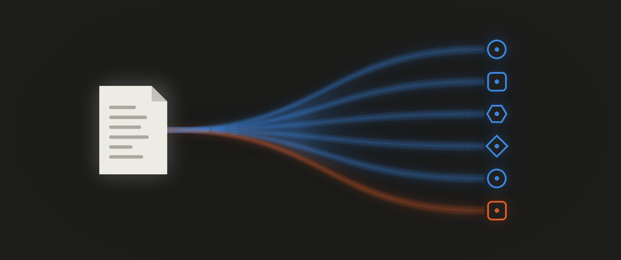

https://github.com/xbill9/gemma4-dev/tree/main/gemini-api-google-hydrogen4

The scores: on 1,319 GSM8K math problems Argon scored 0.9841, Hydrogen and Carbon 0.9803, 3.8 Flash 0.9788, Gemma 4 26B 0.9742, Gemma 4 31B 0.9735 and 3.5 Flash-Lite 0.9629. On 400 BFCL function calls Argon and Gemma 4 31B tied at 0.9675. Gemma 4 ran free; the Gemini runs cost $0.92 to $5.02. Hydrogen answered fastest of the Gemini 4 models, 2.84 s per GSM8K problem against 7.63 s for Argon.

The surprise is in the cost, and it takes the whole picture to see it. Hydrogen is the cheapest Gemini 4 model per token, $7.50 per million output tokens against $10 for Carbon and Argon, and it cost the most per run, $5.02 against $3.46 for Argon. Its thinking eats the token budget: Google's docs say reasoning cannot be turned off on Gemini 4 models, it ran on all 1,319 GSM8K problems at the lowest setting, and it was 55% of the GSM8K bill. Price per token, tokens per answer and thinking per answer together set what a model costs.

#### What Are the New Models?

Gemini 4 Hydrogen, Carbon and Argon are on the Gemini API next to the 3.x Flash models and Gemma 4. Google's pricing page, saved on 2026-11-14 (paid tier, USD per million tokens; output includes thinking tokens):

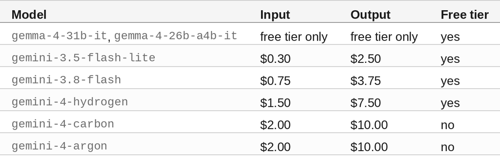

Carbon and Argon go to $4 / $20 on 2026-12-01, and 3.8 Flash to $1.50 / $7.50 on 2027-01-01.

#### What Is the Same for Every Model

Every model got:

- the same endpoint, `/v1beta/openai/chat/completions` on the Gemini API
- the same 1,319 GSM8K and 400 BFCL simple questions, prompts and scoring code
- temperature 0, up to 2,048 tokens per GSM8K answer and 512 per BFCL answer
- eight requests at a time, a 180 s limit per request, up to eight retries
- the same start time: all seven began at 09:11:16 on 2026-11-14
- thinking set as low as each model accepts

Step 2 shows that setting for each model, and the two models that keep thinking at it.

#### At This Point You Should Have…

- A Gemini API key from Google AI Studio, saved in `~/gemini.key`
- Python 3 (the scoring script uses only the standard library)
- A clone of `gemma4-dev`

#### Step 1 — The Endpoint

The Gemini API answers OpenAI chat requests with the key as a Bearer token. Gemma 4 and Gemini take the same request body; only `model` changes:

```bash
curl -sS https://generativelanguage.googleapis.com/v1beta/openai/chat/completions \
  -H "Authorization: Bearer $(cat ~/gemini.key)" -H 'Content-Type: application/json' \
  -d '{"model":"gemma-4-31b-it","temperature":0,"max_tokens":2048,"reasoning_effort":"minimal",
       "messages":[{"role":"user","content":"Janet has 16 eggs, eats 3, bakes with 4, sells the rest at $2. How much does she make? End with Answer: <number>"}]}'
```

The reply ends `Answer: 18`.

#### Step 2 — Thinking Settings, and the Two Models That Keep Thinking

The OpenAI endpoint sets thinking with `reasoning_effort`. `levels.sh` sends the question to every model with each value:

```
gemma-4-31b-it         minimal  thinking 0  finish stop   Answer: 18
gemma-4-31b-it         none     rejected
gemma-4-31b-it         low      rejected
gemma-4-26b-a4b-it     minimal  thinking 0  finish stop   Answer: 18
gemma-4-26b-a4b-it     none     rejected
gemini-3.5-flash-lite  minimal  thinking 0  finish stop   Answer: 18
gemini-3.5-flash-lite  none     rejected
gemini-3.8-flash       minimal  rejected
gemini-3.8-flash       none     thinking 70  finish stop   Answer: 18
gemini-4-hydrogen      minimal  rejected
gemini-4-hydrogen      none     thinking 81  finish stop   Answer: 18
gemini-4-carbon        minimal  rejected
gemini-4-carbon        none     thinking 0  finish stop   Answer: 18
gemini-4-argon         minimal  rejected
gemini-4-argon         none     thinking 0  finish stop   Answer: 18
```

Gemma 4 and Flash-Lite go down to `minimal`, and there they think zero tokens. Hydrogen, 3.8 Flash, Carbon and Argon go down to `none`; Carbon and Argon think zero tokens there, and Hydrogen and 3.8 Flash keep thinking.

Google documents this. Its OpenAI compatibility page says "Reasoning cannot be turned off for Gemini 2.5 Pro, Gemini 3, or Gemini 4 models", and its thinking page lists Hydrogen's levels as `low`, `medium`, `high` and `xhigh`, with `minimal` "Not supported on Gemini 4 models or `gemini-3.8-flash`". The same page documents `none` for 2.5 models only. On Hydrogen, 3.8 Flash, Carbon and Argon the endpoint accepts `none` and treats it as `low`. On the first 100 GSM8K problems (`levels-sample/`), thinking tokens per problem:

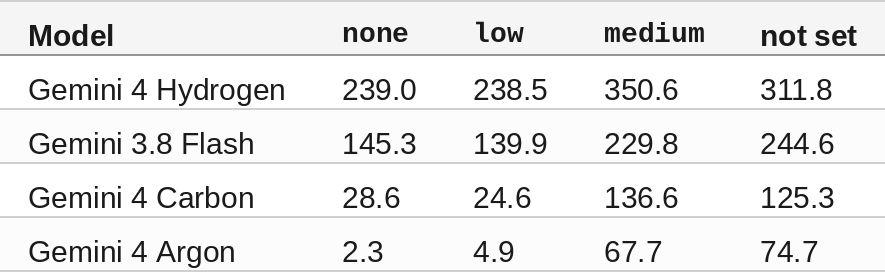

So this run's `none` is each model's lowest documented level, `low`. The native API's other controls give the same result on the test question. `thinking-controls.sh` tries each on Hydrogen and reads the API's own counter, `thoughtsTokenCount`:

```
gemini-4-hydrogen  {"thinkingBudget":0}                          answer 88 thoughts 134 total 292 thought-parts 0
gemini-4-hydrogen  {"thinkingLevel":"NONE"}                      rejected: Invalid value at 'generation_config.thinking_config.thinking_level' (type.googleapis.com/g
gemini-4-hydrogen  {"thinkingLevel":"MINIMAL"}                   rejected: Thinking level MINIMAL is not supported for this model. Please retry with other thinking l
gemini-4-hydrogen  {"thinkingLevel":"LOW"}                       answer 70 thoughts 106 total 246 thought-parts 0
gemini-4-hydrogen  {"thinkingBudget":0,"includeThoughts":true}   answer 73 thoughts 79 total 222 thought-parts 1
```

Across the full run, Hydrogen thought on 1,319 of 1,319 GSM8K problems and all 400 BFCL calls. 3.8 Flash thought on 1,293 GSM8K problems and 113 BFCL calls, Carbon on 268 GSM8K problems, Argon on 66, and Gemma 4 and Flash-Lite on none. Every one of those tokens is billed as output. Hydrogen also thought on "Say hi." (`more-checks.sh`).

#### 🔎 Tip: Thinking Tokens Are Not in `completion_tokens`

On this endpoint `completion_tokens` counts only the visible answer. Thinking is `total_tokens - prompt_tokens - completion_tokens`, and Google bills it as output. The scoring script records it as `reasoning_tokens` on every row.

#### Step 3 — Seven Sibling Rigs

gemma4-dev names a rig `<platform>-<runtime>-<hardware>-<model>`. On the Gemini API the platform is `gemini`, the runtime `api` and the hardware `google`, since Google publishes neither; the model slot is the Gemma size or the Gemini family:

```
gemini-api-google-31b
gemini-api-google-26b
gemini-api-google-flashlite35
gemini-api-google-flash38
gemini-api-google-hydrogen4
gemini-api-google-carbon4
gemini-api-google-argon4
```

Each `tpu.env` names the model and the lowest thinking value it accepts, and the seven `run.sh` files are identical:

```
MODEL_NAME=gemini-4-hydrogen
LOWEST_REASONING_EFFORT=none
```

#### Step 4 — One Scoring Script

[`benchmarks/gen-eval/gen_eval.py`](https://github.com/xbill9/gemma4-dev/tree/main/benchmarks/gen-eval) is the repo's scoring script for GSM8K and BFCL. It is a plain HTTP client in standard Python, so the same script scores a model on a desktop GPU or behind a hosted API. GSM8K is right when the number after `Answer:` matches; BFCL simple is right when the one function call passes BFCL's own checks. Four settings point it at a hosted API:

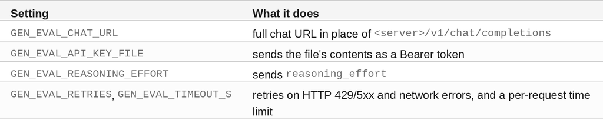

#### Step 5 — Run All Seven Together

```bash
for r in 31b 26b flashlite35 flash38 hydrogen4 carbon4 argon4; do
  gemini-api-google-$r/benchmarks/runs/2026-11-14-accuracy-api/run.sh &
done
2026-11-14 09:11:16 BEGIN gemini-4-argon reasoning_effort=none
2026-11-14 09:18:51 END bfcl_simple rc=0 {"task": "bfcl_simple", "max_tokens": 512, "n": 400, "right": 387, "accuracy": 0.9675, "errors": 0, "truncated": 0, "wall_s": 454.8}
2026-11-14 09:48:10 END gsm8k rc=0 {"task": "gsm8k", "max_tokens": 2048, "n": 1319, "right": 1298, "accuracy": 0.9841, "errors": 0, "truncated": 0, "wall_s": 1759.2}
2026-11-14 09:48:10 DONE
```

Three Gemma 4 requests hit the free tier's rate limit (HTTP 429) after every retry. `resend_errors.py` sent those three again with the same settings and replaced only those rows; all three came back right. Every answer in the table below is a model answer.

#### Step 6 — The Results

`derived.py` builds the table from the saved replies. The cost is the token counts the API returned times the list price.

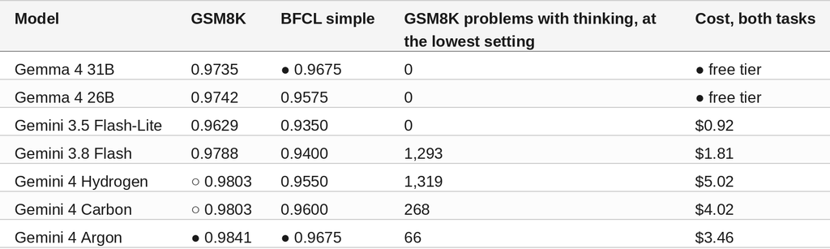

Against Gemma 4 31B on the same questions, counting the questions each got right that the other missed:

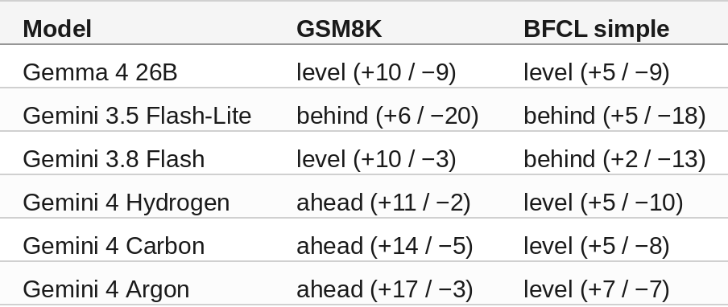

Ahead and behind mean the 95% range of the difference, from 2,000 resamples of the questions, sits entirely above or below zero.

#### Step 7 — Where the Money Goes

By list price Hydrogen is the cheapest Gemini 4 model, $7.50 per million output tokens against $10 for Carbon and Argon. It cost the most because it thought on all 1,319 GSM8K problems at its lowest setting, 248.7 thinking tokens each on average, which made thinking 55% of its GSM8K bill, against 11% for Carbon and 2% for Argon. Argon thought on 66 problems and scored the highest.

The Gemini 4 models also count more input tokens for the same text: the GSM8K prompts are 160,432 tokens to Hydrogen, Carbon and Argon and 120,902 to Gemma 4 31B, Flash-Lite and 3.8 Flash, a mean of 121.6 against 91.7 per problem.

Thinking also shares the output limit with the answer. Google's Hydrogen page says `max_output_tokens` "caps combined thinking and output tokens". At this run's limits of 2,048 and 512 tokens, thinking used the limit before the answer arrived on 4 GSM8K problems and 2 BFCL calls for 3.8 Flash and on 5 GSM8K problems for Carbon; all 11 scored wrong. Sent again with a 16,384-token limit (`cut-rows.py`), 2 of the 4 on 3.8 Flash and 3 of the 5 on Carbon came back right. Hydrogen had no cut answers.

#### Step 8 — Speed

Each reply records how long its request took. All seven models ran at once, eight requests at a time each, over the same connection, so the times are comparable with each other on that morning:

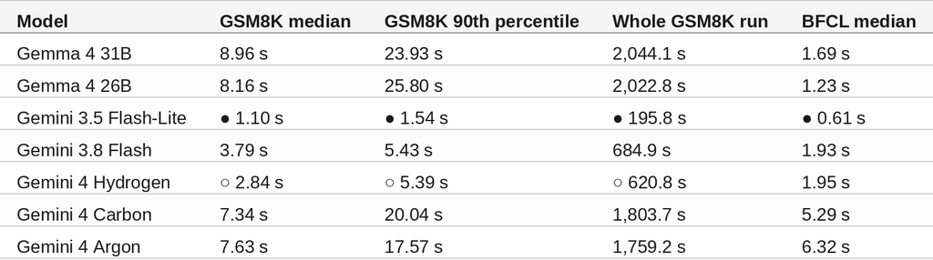

Hydrogen writes about 147.8 tokens per second per request, thinking included, against 26.1 for Argon and 29.7 for Carbon. It finished GSM8K in about a third of Argon's time while thinking on every problem. Flash-Lite was the fastest model overall.

#### Compare and Contrast

[figure not shown]

#### What the API Makes Easy to Miss

Google documents both facts behind Hydrogen's bill: reasoning cannot be turned off on Gemini 4 models, and output prices include thinking tokens. Four things in the API still make the bill easy to misread:

- **Off-looking settings are accepted.** `reasoning_effort: "none"` on the OpenAI endpoint and `thinkingBudget: 0` on the native API return no error on Hydrogen. `none` runs as `low`, and nothing in the reply says thinking is still on.
- **Not setting it costs more.** Hydrogen's default is `high`: 311.8 thinking tokens per problem on the 100-problem sample against 239.0 at `none`.
- **`completion_tokens` leaves thinking out.** A client that reads it sees the visible answer only; on Hydrogen thinking was 55% of the GSM8K bill.
- **The per-token price invites the wrong comparison.** $7.50 against $10 per million output tokens puts Hydrogen below Carbon and Argon; per run it cost 45% more than Argon, $5.02 against $3.46.

Compare models by cost per answer, measured on your own prompts.

#### So, Which One?

For the best scores on short math problems and single function calls with thinking at its lowest setting, Gemini 4 Argon: highest on GSM8K, tied for highest on BFCL, and the cheapest of the three Gemini 4 models per run because it rarely thinks.

For hard, multi-step work, Google points to Carbon. Its Hydrogen page calls Carbon "our strongest frontier model", one that "spends more thinking tokens per turn to test hypotheses and verify edge cases on hard architecture, debugging, science, and security audits", and suggests pairing the two: Carbon plans and resolves hard roadblocks, Hydrogen does the code edits, subagent tasks and test runs. This run held Carbon to its lowest thinking setting, where it thought on 268 of 1,319 GSM8K problems, so that case is untested here. Five of its GSM8K answers were cut at the 2,048-token limit; with a 16,384-token limit 3 of them came back right, which still leaves it below Argon.

Gemini 4 Hydrogen fits four cases:

- **On the free tier.** Hydrogen has one and Carbon and Argon do not. On free quota its thinking costs nothing, and it is the fastest Gemini 4 model, at 0.9803 on GSM8K like Carbon.
- **When response time matters more than cost.** 2.84 s per GSM8K problem against 7.34 s for Carbon and 7.63 s for Argon; 620.8 s for the whole set against 1,759.2 s for Argon.
- **From 2026-12-01.** Carbon and Argon go to $4 / $20. At those prices this run costs $6.93 on Argon and $8.03 on Carbon against $5.02 on Hydrogen, which makes Hydrogen the cheapest Gemini 4 model per run. That is arithmetic from list prices.
- **On hard coding and agent work.** Google's thinking page recommends Hydrogen's default `high` level "for most tasks, including complex coding, agentic execution, tool calling". This run measured short math problems and single function calls, so that case is untested here.

For high-volume simple work on a paid tier, Gemini 3.5 Flash-Lite: $0.92 for both tests, no thinking, 1.10 s per problem, at the cost of being behind Gemma 4 31B on both tests.

For tool calling at no cost, Gemma 4 31B: tied with Argon on BFCL, 0.0106 behind it on GSM8K, free on the Gemini API, and the same weights run on your own hardware.

#### Summary

The goal of this article was to compare the new Gemini 4 models with Gemma 4 on equal terms. The key to the solution was running all seven models through one Gemini API endpoint, started together, with the same questions, scoring script and settings, with thinking set as low as each model accepts. The results were:

- 🟢 Gemini 4 Argon scored highest: 0.9841 on GSM8K and 0.9675 on BFCL simple, for $3.46.
- 🟢 Gemma 4 31B tied Argon on BFCL at 0.9675 and scored 0.9735 on GSM8K, on the free tier.
- 🟢 Hydrogen, Carbon and Argon were ahead of Gemma 4 31B on GSM8K; on BFCL all three were level with it.
- 🟢 Gemma 4 26B was level with the 31B on both tests.
- 🟢 Hydrogen was the fastest Gemini 4 model, 2.84 s per GSM8K problem against 7.34 s for Carbon and 7.63 s for Argon.
- ⚠️ Hydrogen has the lowest Gemini 4 price per token and cost the most per run, $5.02: thinking was 55% of its GSM8K bill.
- ⚠️ Thinking cannot be turned off on Gemini 4 Hydrogen or 3.8 Flash, as Google's docs say. At the lowest setting Hydrogen thought on every problem and 3.8 Flash on 1,293 of 1,319, billed as output.
- ⚠️ The API accepts `none` on Hydrogen without an error and runs it as `low`.
- ⚠️ Thinking shares the output limit: it cut 6 answers on 3.8 Flash and 5 on Carbon at this run's limits.
- 🟢 From 2026-12-01 Hydrogen becomes the cheapest Gemini 4 model per run, $5.02 against $6.93 for Argon, by arithmetic from list prices.
- ⚠️ Thinking tokens are missing from `completion_tokens` on the OpenAI-compatible endpoint.
- ⚠️ Carbon and Argon have no free tier and double in price on 2026-12-01.
- ❌ Gemini 3.5 Flash-Lite and 3.8 Flash were behind Gemma 4 31B on BFCL.

Scope: one laptop in the US calling the Gemini API on 2026-11-14, one run per model, all seven started together. Thinking was set as low as each model accepts: `minimal` for Gemma 4 and Flash-Lite, `none` for the rest, which matched `low` on a 100-problem sample. The native thinking controls were tried on one question. The scores for 3.8 Flash and Carbon include the 11 answers cut by thinking at the 2,048 and 512 token limits. Three Gemma 4 requests that hit the free tier's rate limit were sent again with the same settings. Costs are token counts times list prices. Run times are from one run with all seven sharing one connection, and will move with load on the service. Hard multi-step tasks and higher thinking levels were not measured, which is the work Google positions Carbon for. Google does not say what hardware or engine serves any of these models.

The strategy for comparing Gemini and Gemma 4 on equal terms was validated with an incremental step by step approach.

#### References

- [gemma4-dev on GitHub](https://github.com/xbill9/gemma4-dev)
- [The Gemini API sibling rigs](https://github.com/xbill9/gemma4-dev/tree/main/gemini-api-google-argon4)
- [Evidence for this article](https://github.com/xbill9/gemma4-dev/tree/main/docs/gemini-vs-gemma/evidence)
- [Gemini API pricing](https://aistudio.google.com/docs/pricing)
- [Gemini thinking levels](https://ai.google.dev/gemini-api/docs/thinking)
- [Gemini API OpenAI compatibility](https://ai.google.dev/gemini-api/docs/openai)
- [What's new in Gemini 4 Hydrogen](https://ai.google.dev/gemini-api/docs/whats-new-gemini-4-hydrogen)
- [GSM8K](https://github.com/openai/grade-school-math)
- [Berkeley Function Calling Leaderboard](https://gorilla.cs.berkeley.edu/leaderboard.html)
- [Gemma 4 31B on Hugging Face](https://huggingface.co/google/gemma-4-31B-it)

Hope you enjoyed it!